# Clasification Trees

## Using Tree Package

```r
library(tree) # To construct classification and regression trees
library(ISLR2)
library(tidyverse)
library(caret)
```

We will use the Carseats dataset. A simulated data set containing sales of child car seats at 400 different stores with the following 11 variables

Sales - Unit sales (in thousands) at each location

CompPrice - Price charged by competitor at each location

Income -Community income level (in thousands of dollars)

Advertising -Local advertising budget for company at each location (in thousands of dollars)

Population - Population size in region (in thousands)

Price Price company charges for car seats at each site

ShelveLoc - A factor with levels Bad, Good and Medium indicating the quality of the shelving location for the car seats at each site

Age - Average age of the local population

Education - Education level at each location

Urban - A factor with levels No and Yes to indicate whether the store is in an urban or rural location

US - A factor with levels No and Yes to indicate whether the store is in the US or not

```r
set.seed(1234)
dt <- Carseats
head(dt)
```

|  | Sales | CompPrice | Income | Advertising | Population | Price | ShelveLoc | Age | Education | Urban | US |
| --- | --- | --- | --- | --- | --- | --- | --- | --- | --- | --- | --- |
| 1 | 9.50 | 138 | 73 | 11 | 276 | 120 | Bad | 42 | 17 | Yes | Yes |
| 2 | 11.22 | 111 | 48 | 16 | 260 | 83 | Good | 65 | 10 | Yes | Yes |
| 3 | 10.06 | 113 | 35 | 10 | 269 | 80 | Medium | 59 | 12 | Yes | Yes |
| 4 | 7.40 | 117 | 100 | 4 | 466 | 97 | Medium | 55 | 14 | Yes | Yes |
| 5 | 4.15 | 141 | 64 | 3 | 340 | 128 | Bad | 38 | 13 | Yes | No |
| 6 | 10.81 | 124 | 113 | 13 | 501 | 72 | Bad | 78 | 16 | No | Yes |

```r
summary(dt$Sales)
```

```
   Min. 1st Qu.  Median    Mean 3rd Qu.    Max.
  0.000   5.390   7.490   7.496   9.320  16.270
```

Sales is a continuous variable and we will recode it as a binary variable. Create a binary variable High that takes yes if sales exceed 8 and no otherwise

```r
dt$Sales <- as.factor(ifelse(dt$Sales > 8, "Yes", "No"))
```

We will fit a classification tree and use the summary function to check the internal nodes, terminal nodes and the training error rate.

```r
class_tree <- tree(Sales ~ ., dt)
summary(class_tree)
```

```
Classification tree:
tree(formula = Sales ~ ., data = dt)
Variables actually used in tree construction:
[1] "ShelveLoc"   "Price"       "Income"      "CompPrice"   "Population"  "Advertising" "Age"         "US"
Number of terminal nodes:  27
Residual mean deviance:  0.4575 = 170.7 / 373
Misclassification error rate: 0.09 = 36 / 400
```

Plot the tree using the plot() function. We use the pretty=0 argument to include category names for qualitative predictors.

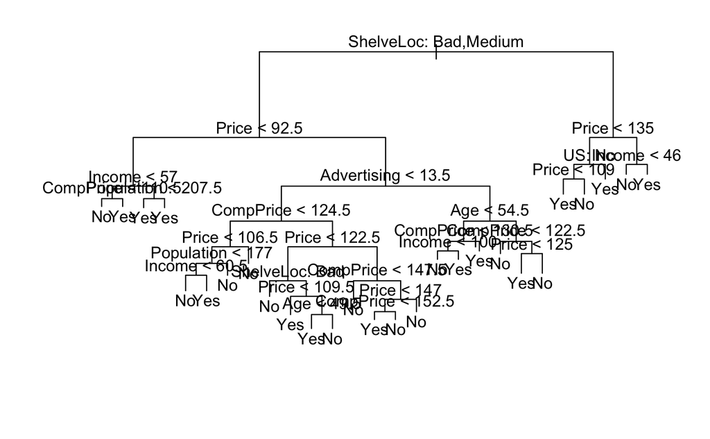

```r
plot(class_tree)
text(class_tree, pretty = 0)
```

Let us split the data into training and test data to evaluate the performance of the tree.

```r
set.seed(1234)
rowPicker <- sample(c(TRUE, FALSE), nrow(dt), replace = TRUE, prob = c(.5, .5))
train <- dt[rowPicker, ]
test <- dt[!rowPicker, ]
```

```r
class_tree <- tree(Sales ~ ., train)
summary(class_tree)
```

```
Classification tree:
tree(formula = Sales ~ ., data = train)
Variables actually used in tree construction:
[1] "Advertising" "Age"         "Price"       "ShelveLoc"   "CompPrice"   "Education"   "Income"
Number of terminal nodes:  18
Residual mean deviance:  0.3493 = 62.53 / 179
Misclassification error rate: 0.07614 = 15 / 197
```

Plot the tree

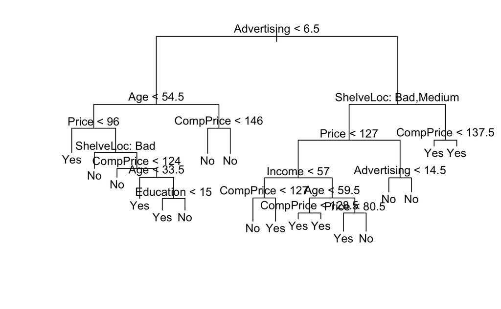

```r
plot(class_tree)
text(class_tree, pretty = 0)
```

```r
tr_pred <- predict(class_tree, test, type = "class")
table(tr_pred, test$Sales)
```

```
tr_pred No Yes
    No  96  36
    Yes 19  52
```

```r
(96+52)/nrow(test)
```

```
[1] 0.729064
```

## Using the caret package and rpart method

```r
library(rpart.plot)
class_tree <- train(Sales ~ ., train %>% select(Sales, US, ShelveLoc), method = "rpart")
class_tree
```

```
CART

197 samples
  2 predictor
  2 classes: 'No', 'Yes'

No pre-processing
Resampling: Bootstrapped (25 reps)
Summary of sample sizes: 197, 197, 197, 197, 197, 197, ...
Resampling results across tuning parameters:

  cp          Accuracy   Kappa
  0.00000000  0.7099778  0.3278964
  0.03947368  0.7137688  0.3264892
  0.25000000  0.6502314  0.1115268

Accuracy was used to select the optimal model using the largest value.
The final value used for the model was cp = 0.03947368.
```

We can find the pruned tree using rpart.plot

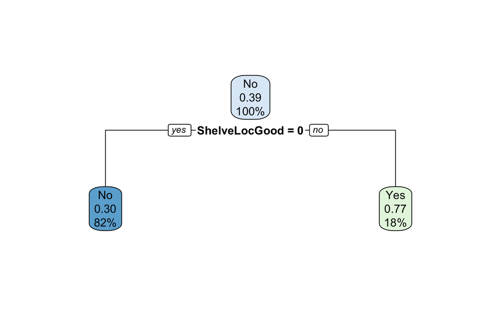

Use the test data to predict

```r
tr_pred <- predict(class_tree, test)
confusionMatrix(tr_pred, test$Sales)
```

```
Confusion Matrix and Statistics

          Reference
Prediction No Yes
       No  99  62
       Yes 16  26

               Accuracy : 0.6158
                 95% CI : (0.5451, 0.683)
    No Information Rate : 0.5665
    P-Value [Acc > NIR] : 0.08874

                  Kappa : 0.1665

 Mcnemar's Test P-Value : 3.483e-07

            Sensitivity : 0.8609
            Specificity : 0.2955
         Pos Pred Value : 0.6149
         Neg Pred Value : 0.6190
             Prevalence : 0.5665
         Detection Rate : 0.4877
   Detection Prevalence : 0.7931
      Balanced Accuracy : 0.5782

       'Positive' Class : No
```

When you are using k-fold crossvalidation, you use the same method as above except you add a control term.